# QTW Case Study 7 - Final

Author

Nicholas Sager, Will Jones

Published

August 4, 2024

## Introduction

The goal of this Case Study is to predict the class of a variable that we don’t know anything about. The data is anonymized and we are not concerned with explaining the predictions. False positives of class ‘1’ incur a cost of $17. False negatives of (class ‘0’) incur a cost of $5. Given these, our goal is to develop a model that minimizes financial loss.

## Data Processing and Exploration

### Summary Statistics

Our dataset has two classes. They are labelled ‘1.0’ and ‘0.0’ and are split relatively evenly. There are approximately 95,000 records labelled ‘0’ and 64,000 records labelled ‘1’.

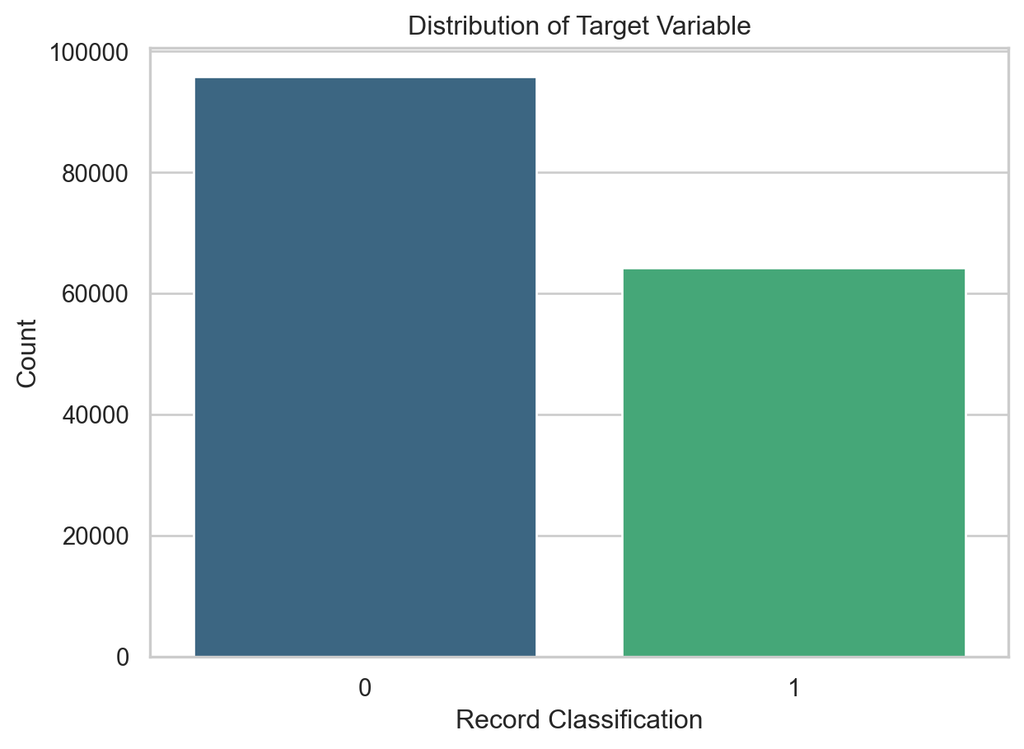

Figure 1: Distribution of Target Variable (y).

We will explore some of the features to gain intuition on the dataset. Starting with the categorical variables:

The ‘x24’ variable appears to represent continents. Asia is the most common continent in the dataset with approximately 140,000 records. The other continents have fewer records, with America having the fewest at around 5,000 records and Europe splitting the difference.

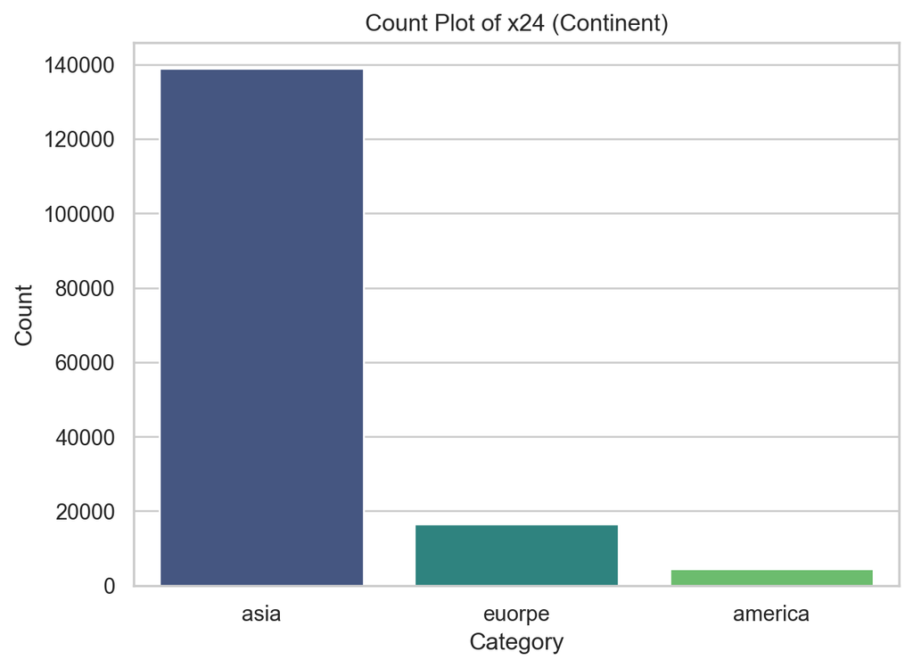

Figure 2: Distribution of Continent Variable. Asia is the most common.

The ‘x29’ variable appears to represent months. The majority of records are for summer months, with July and June having the most records. December has the fewest records. Many of the month labels in the dataset are irregular or misspelled so these are mapped to the full month names for clarity.

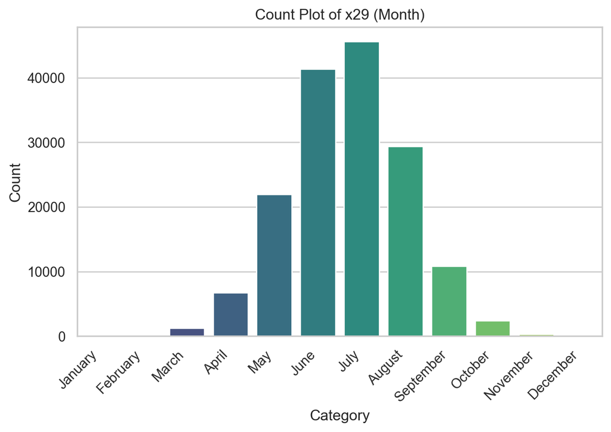

Figure 3: Distribution of Month Variable. The majority of records are for summer months.

The ‘x30’ variable appears to represent the day of the week. The majority of records are in the middle of the work week with Tuesday, Wednesday, and Thursday having the most records. Monday and Friday have fewer records. Again, the spellings are irregular so these are mapped to the full day names for clarity.

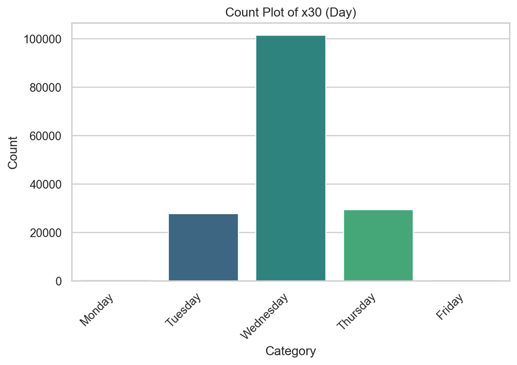

Figure 4: Distribution of Day Variable. Most records are in the middle of the work week.

The ‘x32’ variable appears to represent a percentage change. The distribution of this variable is shown below. Most records tend toward smaller absolute values of changes, with the most common changes being 0.0%, and 0.01%. We have chosen to keep this feature as a categorical variable for now, but we could consider converting it to a numeric variable in the future. There are relatively few categories and they are nicely rounded so it’s doubtful that the model would benefit from the increased complexity of a continuous variable for this feature. The 0.0% category was originally counted as separate from -0.0%. We have combined them for simplicity since they are the same.

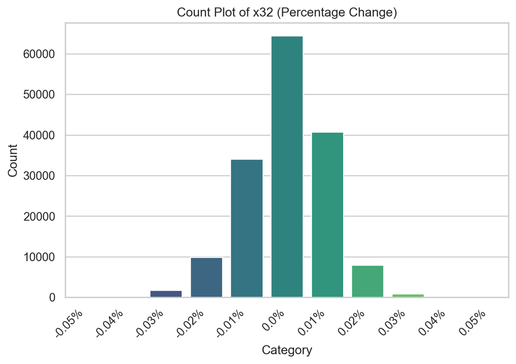

Figure 5: Distribution of Percentage Change Variable. Most records tend toward smaller changes.

‘x37’ value represents monetary values. The distribution is shown below of the values. The distribution centers around $0 with a normal distribution ranging from $-4000 to $4000. We have choosen to convert this to a float value.

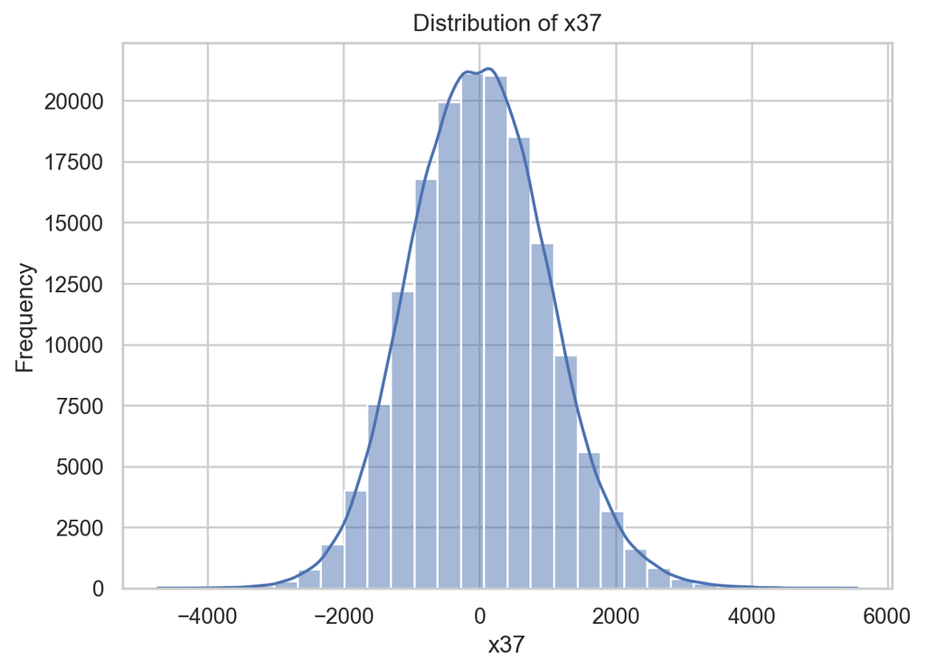

Figure 6: Distribution of Monetary variable. Records show a normal distribution ranging from -4000 to 4000.

To better understand the distribution of the other features, we can plot a histogram of the ‘x20’ variable. The ‘x20’ variable appears to be normally distributed. We could also plot histograms of other features, but for brevity, we will only show the distribution of ‘x20’.

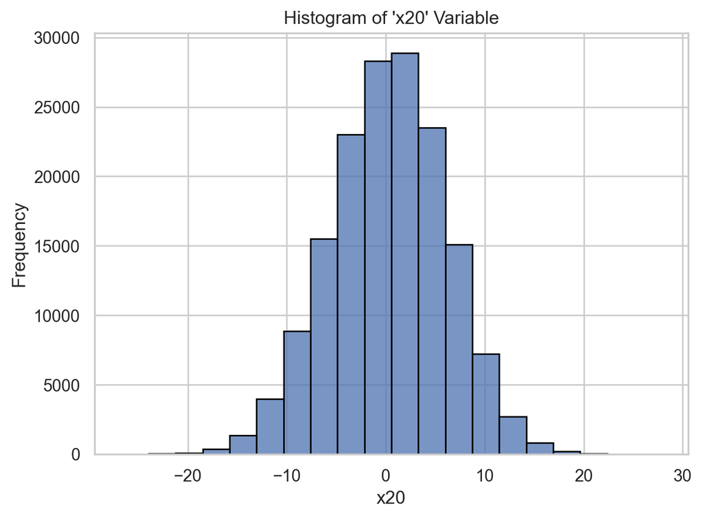

Figure 7: Distribution of x20 Variable. This variable appears to be Normally distributed.

### Missing Data

Before modelling, we investigate the missing values by feature and class. The table below shows the percentage of missing values for each class. The total percentage of missing values is also shown. Values are missing nearly identically between the two target classes, and seem to be evenly distributed across the features. We conclude that the data is missing completely at random.

Table 1: Missing data summary by attribute (top 10 only). The table shows the number and percentage of missing values in the dataset.

|  | Missing Values | Percentage | Percentage Class 0 | Percentage Class 1 |
| --- | --- | --- | --- | --- |
| x23 | 47 | 0.03 | 0.03 | 0.03 |
| x10 | 43 | 0.03 | 0.03 | 0.02 |
| x34 | 41 | 0.03 | 0.02 | 0.03 |
| x33 | 41 | 0.03 | 0.03 | 0.02 |
| x44 | 40 | 0.02 | 0.03 | 0.02 |
| x18 | 40 | 0.02 | 0.02 | 0.03 |
| x41 | 40 | 0.02 | 0.02 | 0.03 |
| x31 | 39 | 0.02 | 0.02 | 0.03 |
| x20 | 38 | 0.02 | 0.03 | 0.02 |
| x2 | 38 | 0.02 | 0.02 | 0.03 |
| Total | 1608 | 0.02 | 0.02 | 0.02 |

The proportion of missing data is relatively low, with most features having less than 2% or 3% missing values. Because the data is missing completely at random, we can impute the missing values with the median of the feature.

## Model Building

To classify the records, we will fit a dense Neural Network and another model. Whichever model minimizes financial loss will be selected as the final classifier. We will evaluate the models in validation primarily on the financial loss. We will also use accuracy and other classification metrics such as precision and recall for reference.

### Data Preparation

Before fitting models, we need to prepare the data. We will scale the numerical features using the StandardScaler. Categorical variables will be one-hot encoded. We will then split the data into five folds for cross-validation. We will fit the model on four folds and validate on the remaining fold. We will store the out-of-fold predictions and use them to evaluate the model.

### Dense Neural Network

The data is split into five folds for cross-validation and to compute the out-of-fold predictions. The model is trained with early stopping and dropout layers to prevent over-fitting. Out-of-fold predictions are stored for the entire dataset and used to evaluate overall performance.

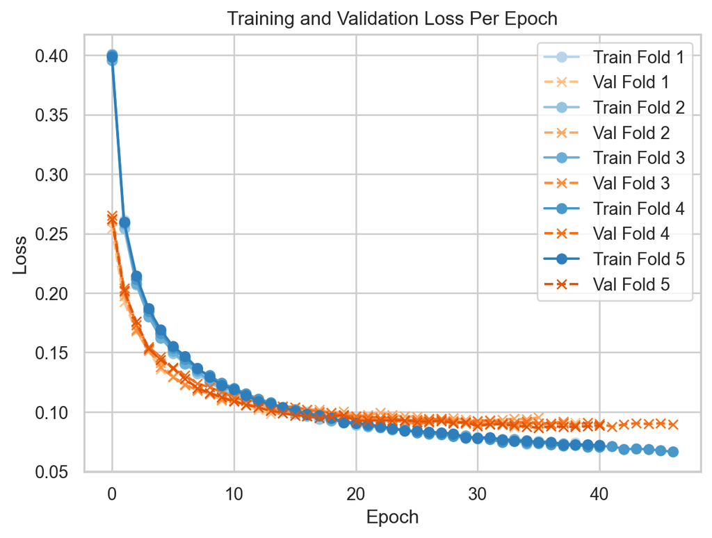

Figure 8: Training and Validation Losses per fold for each epoch in the Neural Network model.

The model has been trained with binary cross-entropy which effectively will maximize prediction accuracy. Since we are more concerned with financial loss, we then choose the prediction threshold that minimizes the financial loss. We calculate the financial loss across different thresholds using the financial loss function. The optimal threshold is approximately 0.8. We then evaluate the model using the optimal threshold and calculate the financial loss of approximately $0.24 per record with the Neural Network. The financial loss and its components across a range of thresholds is shown below.

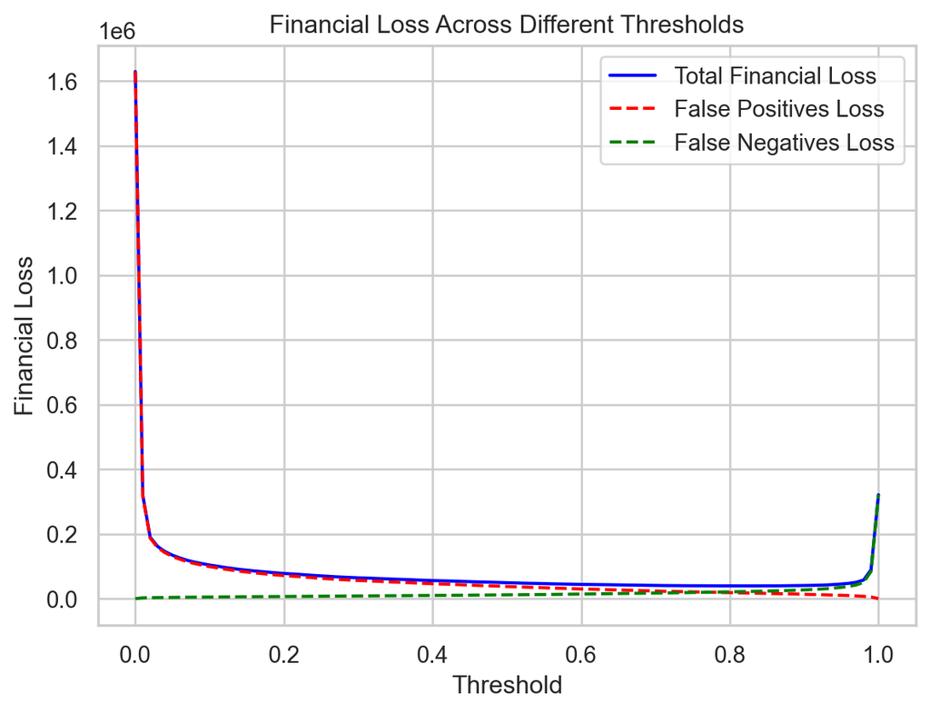

Figure 9: Total, False Positive, and False Negative Financial Losses Across Different Thresholds.

```
Model: "sequential_4"
```

```
┏━━━━━━━━━━━━━━━━━━━━━━━━━━━━━━━━━┳━━━━━━━━━━━━━━━━━━━━━━━━┳━━━━━━━━━━━━━━━┓
┃ Layer (type)                    ┃ Output Shape           ┃       Param # ┃
┡━━━━━━━━━━━━━━━━━━━━━━━━━━━━━━━━━╇━━━━━━━━━━━━━━━━━━━━━━━━╇━━━━━━━━━━━━━━━┩
│ dense_20 (Dense)                │ (None, 256)            │        19,968 │
├─────────────────────────────────┼────────────────────────┼───────────────┤
│ dropout_12 (Dropout)            │ (None, 256)            │             0 │
├─────────────────────────────────┼────────────────────────┼───────────────┤
│ dense_21 (Dense)                │ (None, 64)             │        16,448 │
├─────────────────────────────────┼────────────────────────┼───────────────┤
│ dropout_13 (Dropout)            │ (None, 64)             │             0 │
├─────────────────────────────────┼────────────────────────┼───────────────┤
│ dense_22 (Dense)                │ (None, 32)             │         2,080 │
├─────────────────────────────────┼────────────────────────┼───────────────┤
│ dropout_14 (Dropout)            │ (None, 32)             │             0 │
├─────────────────────────────────┼────────────────────────┼───────────────┤
│ dense_23 (Dense)                │ (None, 16)             │           528 │
├─────────────────────────────────┼────────────────────────┼───────────────┤
│ dense_24 (Dense)                │ (None, 1)              │            17 │
└─────────────────────────────────┴────────────────────────┴───────────────┘
```

```
 Total params: 117,125 (457.52 KB)
```

```
 Trainable params: 39,041 (152.50 KB)
```

```
 Non-trainable params: 0 (0.00 B)
```

```
 Optimizer params: 78,084 (305.02 KB)
```

Table 2: Dense Neural Network Cross-Validation Classification Report

|  | precision | recall | f1-score | support |
| --- | --- | --- | --- | --- |
| 0.0 | 0.955 | 0.99 | 0.972 | 95803 |
| 1.0 | 0.983 | 0.93 | 0.956 | 64197 |
| accuracy |  |  | 0.966 | 0.966 |
| macro avg | 0.969 | 0.96 | 0.964 | 160000 |
| weighted avg | 0.966 | 0.966 | 0.966 | 160000 |

### Random Forest Classifier

To verify that the more advanced model is worth the effort, we also train a Random Forest Classifier. To optimize performance, we split the data into train and test splits and use a randomized search to find the best hyperparameters for the model. The overall financial loss and other metrics are then evaluated on the entire dataset using cross-validation.

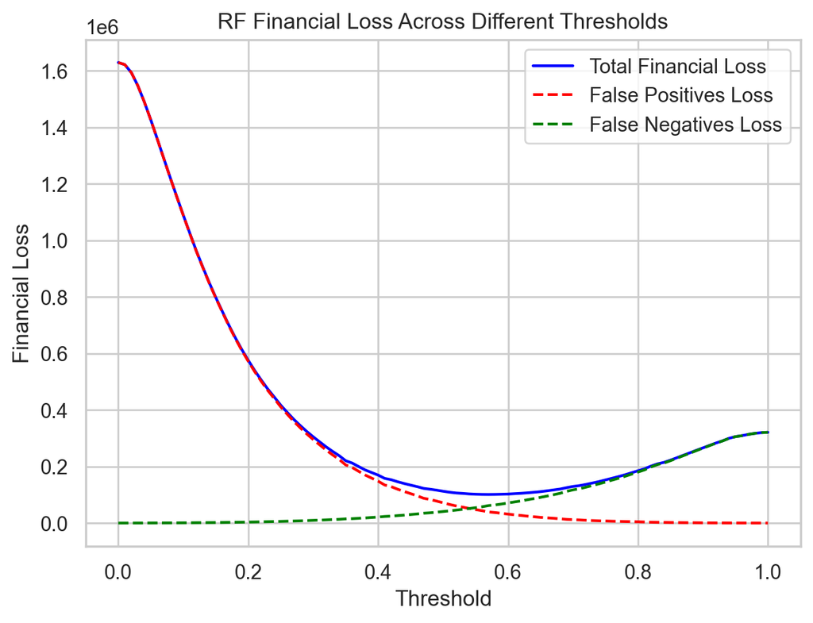

Figure 10: Total, False Positive, and False Negative Financial Losses Across Different Thresholds. Random Forest Classifier.

The Random Forest classifier is trained with the best parameters from the randomized search. They are 300 estimators, 2 samples per split, max depth of 75, and Gini criterion. We then evaluate the model with these parameters using 5-fold cross validation. The average financial loss for this model is $0.63 per record. The other overall classification metrics are worse than the Neural Network.

Table 3: Random Forest Cross-Validation Classification Report

|  | precision | recall | f1-score | support |
| --- | --- | --- | --- | --- |
| Class 0 | 0.883 | 0.976 | 0.927 | 95803 |
| Class 1 | 0.957 | 0.807 | 0.876 | 64197 |
| accuracy |  |  | 0.908 | 0.908 |
| macro avg | 0.92 | 0.892 | 0.902 | 160000 |
| weighted avg | 0.913 | 0.908 | 0.907 | 160000 |

### XGBoost Classifier

To provide another comparison model to Random Forest and Dense Network, we constructed a XGBoost model. To create the best model, we used hyperparameter tuning paired with a Randomized Grid Search CV with 5 folds.

The loss function for our train and validation is shown in the chart below. The average financial loss for this model is $0.58 per record. The other classification metrics are shown in the classification report and are worse than the Dense Network but better than the Random Forest model.

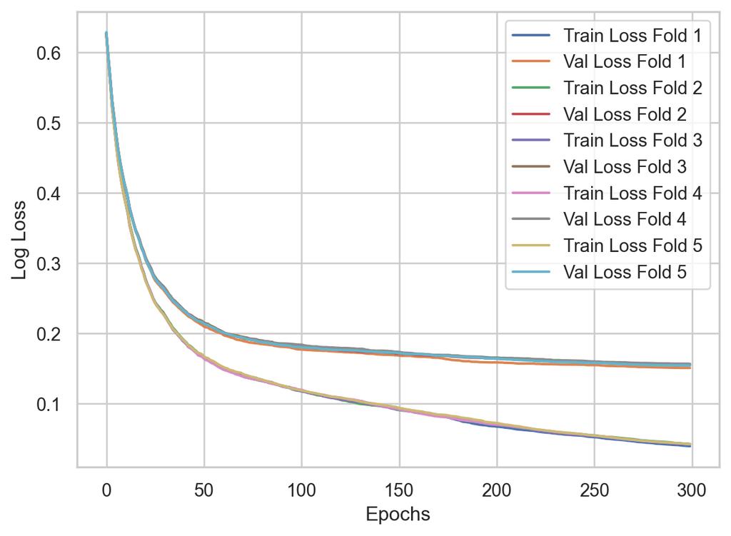

Figure 11: Training and Validation Losses per fold for each iteration in the XGBoost model.

Table 4: XGBoost Cross-Validation Classification Report

|  | precision | recall | f1-score | support |
| --- | --- | --- | --- | --- |
| Class 0 | 0.947 | 0.959 | 0.953 | 95803 |
| Class 1 | 0.938 | 0.92 | 0.929 | 64197 |
| accuracy |  |  | 0.943 | 0.943 |
| macro avg | 0.942 | 0.939 | 0.941 | 160000 |
| weighted avg | 0.943 | 0.943 | 0.943 | 160000 |

## Results and Discussion

### Classifier Performance

The final classifier is largely effective at reducing financial loss. As shown by the higher precision (0.98) and lower recall (0.93) for class 1 in the confusion matrix, the model is most incentivized to minimize false positives. This comes at the cost of a slight reduction in total accuracy compared to the training. Adjusting the threshold to accomplish this results in a lower precision (0.95) and higher recall (0.99) for class 0. The resulting financial loss computed on out-of sample predictions over the entire dataset is $0.25 per record or approximately $40,000. Though we don’t know much else about this problem, this is presumably offset by some sort of gain for correct predictions. As shown in discussion of threshold in the neural network section above, the financial loss is relatively constant across most thresholds. Thus most of the gains have come from training the model to have accurate predictions. Tuning the threshold with these particular losses mostly serves to optimize as much as possible.

|  | Model | Total Financial Loss | Average Financial Loss Per Sample | Overall Accuracy | Precision | Recall | ROC-AUC |
| --- | --- | --- | --- | --- | --- | --- | --- |
| 0 | Neural Network | 39464 | 0.247 | 0.972 | 0.966 | 0.964 | 0.992 |
| 1 | XGBoost | 92438 | 0.578 | 0.943 | 0.938 | 0.92 | 0.939 |
| 2 | Random Forest | 101125 | 0.632 | 0.908 | 0.957 | 0.807 | 0.975 |

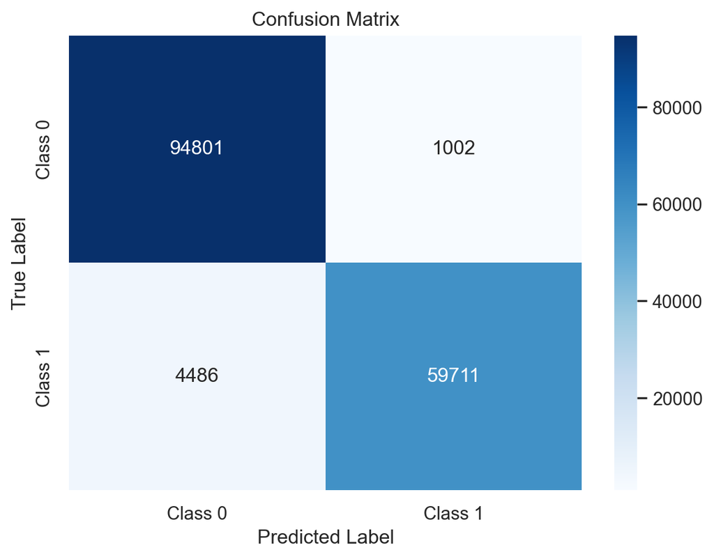

Figure 12: Dense NN Classifier Confusion Matrix. Out-of-fold predictions are used to evaluate the model.

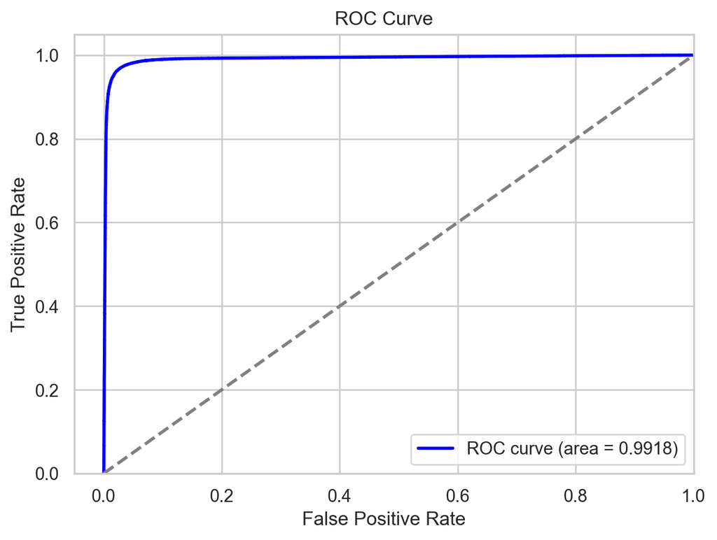

Figure 13: Dense NN Classifier ROC Curve. Out-of-fold predictions are used to evaluate the model.

Table 6: Dense NN Classification Report. The table shows the precision, recall, f1-score, and support for each class. Out-of-fold predictions are used to evaluate the model.

|  | precision | recall | f1-score | support |
| --- | --- | --- | --- | --- |
| Clas 0 | 0.955 | 0.99 | 0.972 | 95803 |
| Class 1 | 0.983 | 0.93 | 0.956 | 64197 |
| accuracy |  |  | 0.966 | 0.966 |
| macro avg | 0.969 | 0.96 | 0.964 | 160000 |
| weighted avg | 0.966 | 0.966 | 0.966 | 160000 |

## Appendix

### Python Code

```python
import matplotlib.pyplot as plt
import numpy as np
import seaborn as sns
import pandas as pd
import os

from IPython.display import Markdown
import xgboost as xgb
from xgboost import XGBClassifier
import tensorflow as tf

from sklearn.ensemble import RandomForestClassifier
from sklearn.preprocessing import StandardScaler, OneHotEncoder
from sklearn.compose import ColumnTransformer
from sklearn.pipeline import Pipeline
from sklearn.model_selection import (
    KFold,
    train_test_split,
    RandomizedSearchCV,
    cross_val_score,
    cross_val_predict,
)
from sklearn.metrics import (
    confusion_matrix,
    classification_report,
    roc_auc_score,
    roc_curve,
    accuracy_score,
    precision_score,
    recall_score,
    f1_score,
    make_scorer,
)
```

```python
directory = "./Case-Study-7-final/data" if os.path.exists("./Case-Study-7-final/data") else "./data"
data = pd.read_csv(f"{directory}/final_project(5).csv")

# print(data)
print(data.dtypes)
```

```
x0     float64
x1     float64
x2     float64
x3     float64
x4     float64
x5     float64
x6     float64
x7     float64
x8     float64
x9     float64
x10    float64
x11    float64
x12    float64
x13    float64
x14    float64
x15    float64
x16    float64
x17    float64
x18    float64
x19    float64
x20    float64
x21    float64
x22    float64
x23    float64
x24     object
x25    float64
x26    float64
x27    float64
x28    float64
x29     object
x30     object
x31    float64
x32     object
x33    float64
x34    float64
x35    float64
x36    float64
x37     object
x38    float64
x39    float64
x40    float64
x41    float64
x42    float64
x43    float64
x44    float64
x45    float64
x46    float64
x47    float64
x48    float64
x49    float64
y        int64
dtype: object
```

```python
# print(data["y"].value_counts())

sns.set_theme(style="whitegrid")

# Plot the distribution of target variable (category)
# plt.figure(figsize=(8, 6))
sns.countplot(x="y", data=data, palette="viridis")
plt.title("Distribution of Target Variable")
plt.xlabel("Record Classification")
plt.ylabel("Count")
plt.show()
# print(data["x24"].value_counts())

sorted_data = data['x24'].value_counts().index

# plt.figure(figsize=(8, 6))
sns.countplot(x="x24", data=data, order=sorted_data, palette="viridis")
plt.title("Count Plot of x24 (Continent)")
plt.xlabel("Category")
plt.ylabel("Count")
plt.show()
month_mapping = {
    'July': 'July',
    'Jun': 'June',
    'Aug': 'August',
    'May': 'May',
    'sept.': 'September',
    'Apr': 'April',
    'Oct': 'October',
    'Mar': 'March',
    'Nov': 'November',
    'Feb': 'February',
    'Dev': 'December',
    'January': 'January'
}

data['x29'] = data['x29'].replace(month_mapping)
```

```python
# print(data["x29"].value_counts())
month_order = ['January', 'February', 'March', 'April', 'May', 'June', 'July', 'August', 'September', 'October', 'November', 'December']

# plt.figure(figsize=(8, 6))
sns.countplot(x="x29", data=data, order=month_order, palette="viridis")
plt.title("Count Plot of x29 (Month)")
plt.xlabel("Category")
plt.ylabel("Count")
plt.xticks(rotation=45, ha="right")
plt.tight_layout()
plt.show()
day_mapping = {
  "monday": "Monday",
  "tuesday": "Tuesday",
  "wednesday": "Wednesday",
  "thurday": "Thursday",
  "friday": "Friday",
}

data['x30'] = data['x30'].replace(day_mapping)
```

```python
# print(data["x30"].value_counts())
day_order = ['Monday', 'Tuesday', 'Wednesday', 'Thursday', 'Friday']

# plt.figure(figsize=(8, 6))
sns.countplot(x="x30", data=data, order=day_order, palette="viridis")
plt.title("Count Plot of x30 (Day)")
plt.xlabel("Category")
plt.ylabel("Count")
plt.xticks(rotation=45, ha="right")
plt.tight_layout()
plt.show()
data['x32'] = data['x32'].replace('-0.0%', '0.0%')
# print(data['x32'].value_counts())
```

```python
# print(data["x32"].value_counts())
change_order = ['-0.05%', '-0.04%', '-0.03%', '-0.02%', '-0.01%', '0.0%', '0.01%', '0.02%', '0.03%', '0.04%', '0.05%']

# plt.figure(figsize=(8, 6))
sns.countplot(x="x32", data=data, order=change_order, palette="viridis")
plt.title("Count Plot of x32 (Percentage Change)")
plt.xlabel("Category")
plt.ylabel("Count")
plt.xticks(rotation=45, ha="right")
plt.tight_layout()
plt.show()
data['x37'] = data['x37'].replace('[\$,]', '', regex=True).astype(float)
#Histogtam
# plt.figure(figsize=(10, 6))
sns.histplot(data['x37'], bins=30, kde=True)
plt.title('Distribution of x37')
plt.xlabel('x37')
plt.ylabel('Frequency')
plt.show()
```

```python
# plt.figure(figsize=(8, 6))
sns.histplot(data["x20"], bins=20, kde=False, edgecolor="black")
# plt.hist(data['x20'], bins=20, edgecolor='black')
plt.title("Histogram of 'x20' Variable")
plt.xlabel("x20")
plt.ylabel("Frequency")
plt.show()
```

```python
missing_by_column = data.isnull().sum()
total_missing = missing_by_column.sum()

missing_summary = pd.DataFrame(missing_by_column, columns=["Missing Values"])
missing_summary.loc["Total"] = total_missing

print(missing_summary)
```

```
       Missing Values
x0                 26
x1                 25
x2                 38
x3                 37
x4                 26
x5                 37
x6                 26
x7                 27
x8                 21
x9                 30
x10                43
x11                30
x12                36
x13                31
x14                34
x15                35
x16                26
x17                27
x18                40
x19                35
x20                38
x21                29
x22                27
x23                47
x24                28
x25                22
x26                36
x27                30
x28                35
x29                30
x30                30
x31                39
x32                31
x33                41
x34                41
x35                30
x36                27
x37                23
x38                31
x39                23
x40                36
x41                40
x42                26
x43                37
x44                40
x45                29
x46                31
x47                37
x48                32
x49                32
y                   0
Total            1608
```

```python
missing_by_column = data.isnull().sum()
total_entries = len(data)
missing_percentage = (missing_by_column / total_entries) * 100

class0_missing = data[data["y"] == 0].isnull().sum()
class1_missing = data[data["y"] == 1].isnull().sum()
class0_percentage = (class0_missing / len(data[data["y"] == 0])) * 100
class1_percentage = (class1_missing / len(data[data["y"] == 1])) * 100

total_missing = missing_by_column.sum()
total_percentage = (total_missing / (total_entries * len(data.columns))) * 100

missing_summary = pd.DataFrame(
    {
        "Missing Values": missing_by_column,
        "Percentage": missing_percentage,
        "Percentage Class 0": class0_percentage,
        "Percentage Class 1": class1_percentage,
    }
)
# missing_summary.loc["Total"] = [total_missing, total_percentage]
missing_summary.loc["Total"] = [
    total_missing,
    total_percentage,
    (class0_missing.sum() / (len(data.columns) * len(data[data["y"] == 0])) * 100),
    (class1_missing.sum() / (len(data.columns) * len(data[data["y"] == 1])) * 100),
]

# Sort and display the top 15 missing values
sorted_missing_summary = missing_summary.drop("Total").sort_values(
    "Percentage", ascending=False
).head(10)
sorted_missing_summary = pd.concat(
    [sorted_missing_summary, missing_summary.loc[["Total"]]]
)
sorted_missing_summary = sorted_missing_summary.round(2)

print(sorted_missing_summary)
```

```
       Missing Values  Percentage  Percentage Class 0  Percentage Class 1
x23              47.0        0.03                0.03                0.03
x10              43.0        0.03                0.03                0.02
x34              41.0        0.03                0.02                0.03
x33              41.0        0.03                0.03                0.02
x44              40.0        0.02                0.03                0.02
x18              40.0        0.02                0.02                0.03
x41              40.0        0.02                0.02                0.03
x31              39.0        0.02                0.02                0.03
x20              38.0        0.02                0.03                0.02
x2               38.0        0.02                0.02                0.03
Total          1608.0        0.02                0.02                0.02
```

```python
missing_md = sorted_missing_summary.to_markdown()
Markdown(missing_md)
```

```python
numeric_cols = data.select_dtypes(include=['number']).columns
categorical_cols = data.select_dtypes(include=['object', 'category']).columns

for col in numeric_cols:
    median_value = data[col].median()
    data[col] = data[col].fillna(median_value)

for col in categorical_cols:
    mode_value = data[col].mode()[0]
    data[col] = data[col].fillna(mode_value)

print(f"Remaining missing data: {data.isnull().sum().sum()}")
```

```
Remaining missing data: 0
```

```python
# Make arrays
target_column = 'y'
X_raw = data.drop(columns=[target_column])
y = data[target_column]

# Categorical to onehot and numerical to standard scaler
numeric_cols = X_raw.select_dtypes(include=['number']).columns
categorical_cols = X_raw.select_dtypes(include=['object', 'category']).columns

preprocessor = ColumnTransformer(
    transformers=[
        ('num', StandardScaler(), numeric_cols),
        ('cat', OneHotEncoder(handle_unknown='ignore'), categorical_cols)
    ]
)

pipeline = Pipeline(steps=[
    ('preprocessor', preprocessor)
])

X = pipeline.fit_transform(X_raw)

kf = KFold(n_splits=5, shuffle=True, random_state=137)
```

```python
# Primary financial loss function, use for evaluation
def calculate_financial_components(y_true, y_probs, threshold):
    y_pred = (y_probs >= threshold).astype(int)
    fp = np.sum((y_true == 0) & (y_pred == 1))
    fn = np.sum((y_true == 1) & (y_pred == 0))
    total_loss = fp * 17 + fn * 5
    return total_loss, fp * 17, fn * 5

# Note: These don't work for tf. probably better to minimize normal loss and then tune threshold
# Scikit-learn
def financial_loss_skl(y_true, y_pred):
    fp = ((y_true == 0) & (y_pred == 1)).sum() * 17  # False Positives
    fn = ((y_true == 1) & (y_pred == 0)).sum() * 5   # False Negatives
    return fp + fn

financial_loss_scorer_skl = make_scorer(financial_loss_skl, greater_is_better=False)

# TensorFlow - reworked to be differentiable
def financial_loss_tf(y_true, y_pred):
    # y_pred are the predicted probabilities
    y_pred = tf.clip_by_value(y_pred, 1e-7, 1 - 1e-7)
    # Cost matrix
    fp_cost = 17.0
    fn_cost = 5.0
    # Calculating the cost
    loss = y_true * (1 - y_pred) * fn_cost + (1 - y_true) * y_pred * fp_cost
    return tf.reduce_mean(loss)

# XGBoost
def custom_objective_xgb(preds, dtrain):
    labels = dtrain.get_label()
    preds = 1.0 / (1.0 + np.exp(-preds))  # Transform predictions to probability
    fp_grad = 17 * (labels - preds) * (labels == 0)
    fn_grad = 5 * (preds - labels) * (labels == 1)
    grad = fp_grad + fn_grad
    hess = preds * (1 - preds)
    return grad, hess
```

```python
# Attempt to use more of computer
tf.config.threading.set_intra_op_parallelism_threads(8)  # Set to the number of cores in your machine
tf.config.threading.set_inter_op_parallelism_threads(2)

def build_model(input_shape):
    model = tf.keras.models.Sequential([
        tf.keras.layers.Dense(256, activation='relu', input_shape=(input_shape,)),
        tf.keras.layers.Dropout(0.2),
        tf.keras.layers.Dense(64, activation='relu'),
        tf.keras.layers.Dropout(0.2),
        tf.keras.layers.Dense(32, activation='relu'),
        tf.keras.layers.Dropout(0.2),
        tf.keras.layers.Dense(16, activation='relu'),
        tf.keras.layers.Dense(1, activation='sigmoid')
    ])
    model.compile(optimizer="adam", loss="binary_crossentropy", metrics=["accuracy"])
    return model


kf = KFold(n_splits=5, shuffle=True, random_state=42)

oof_preds = np.zeros(len(X))
oof_true = np.zeros(len(X))

# Lists to store the metrics for each fold
accuracy_list = []
precision_list = []
recall_list = []
f1_list = []

train_losses = []
val_losses = []

for train_index, val_index in kf.split(X):
    early_stopping = tf.keras.callbacks.EarlyStopping(
        monitor="val_loss", patience=5, restore_best_weights=True
    )
    X_train, X_val = X[train_index], X[val_index]
    y_train, y_val = y[train_index], y[val_index]

    model = build_model(X_train.shape[1])
    history = model.fit(
        X_train,
        y_train,
        epochs=100,
        batch_size=256,
        verbose=1,
        validation_data=(X_val, y_val),
        callbacks=[early_stopping],
    )

    # Append losses for each epoch
    train_losses.append(history.history['loss'])
    val_losses.append(history.history['val_loss'])

    y_pred = model.predict(X_val).flatten()

    # Store the predictions and true values
    oof_preds[val_index] = y_pred
    oof_true[val_index] = y_val

    # Convert probabilities to binary predictions
    y_pred_binary = (y_pred > 0.5).astype(int)

    # Calculate and store metrics for the current fold
    accuracy_list.append(accuracy_score(y_val, y_pred_binary))
    precision_list.append(precision_score(y_val, y_pred_binary))
    recall_list.append(recall_score(y_val, y_pred_binary))
    f1_list.append(f1_score(y_val, y_pred_binary))
```

```python
# Plotting training and validation losses
fig, ax = plt.subplots()

colors_train = plt.cm.Blues(np.linspace(0.3, 0.7, len(train_losses)))
colors_val = plt.cm.Oranges(np.linspace(0.3, 0.7, len(val_losses)))

for i in range(len(train_losses)):
    ax.plot(train_losses[i], label=f'Train Fold {i+1}', color=colors_train[i], linestyle='-', marker='o')
    ax.plot(val_losses[i], label=f'Val Fold {i+1}', color=colors_val[i], linestyle='--', marker='x')

ax.set_title('Training and Validation Loss Per Epoch')
ax.set_xlabel('Epoch')
ax.set_ylabel('Loss')
ax.legend()
plt.show()
```

```python
# Evaluate financial impact across thresholds
thresholds = np.linspace(0, 1, 101)
total_losses = []
fp_losses = []
fn_losses = []

for t in thresholds:
    total_loss, fp_loss, fn_loss = calculate_financial_components(oof_true, oof_preds, t)
    total_losses.append(total_loss)
    fp_losses.append(fp_loss)
    fn_losses.append(fn_loss)

optimal_threshold = thresholds[np.argmin(total_losses)]
print(f"Optimal threshold: {optimal_threshold}")

optimal_loss = total_losses[np.argmin(total_losses)]
avg_loss = optimal_loss / len(oof_true)
print(f"Financial loss at optimal threshold: {avg_loss}")
```

```
Optimal threshold: 0.8300000000000001
Financial loss at optimal threshold: 0.24665
```

```python
# plt.figure(figsize=(10, 6))
plt.plot(thresholds, total_losses, label='Total Financial Loss', color='blue')
plt.plot(thresholds, fp_losses, label='False Positives Loss', linestyle='--', color='red')
plt.plot(thresholds, fn_losses, label='False Negatives Loss', linestyle='--', color='green')

plt.title('Financial Loss Across Different Thresholds')
plt.xlabel('Threshold')
plt.ylabel('Financial Loss')
plt.legend()
plt.grid(True)
plt.show()
```

```python
# Convert from probabilities to binary predictions
oof_preds_binary = (oof_preds > optimal_threshold).astype(int)

# Compute metrics for the entire dataset
accuracy = accuracy_score(oof_true, oof_preds_binary)
precision = precision_score(oof_true, oof_preds_binary)
recall = recall_score(oof_true, oof_preds_binary)
f1 = f1_score(oof_true, oof_preds_binary)
roc_auc = roc_auc_score(oof_true, oof_preds)

# Calculate mean and standard deviation of metrics for each fold
mean_accuracy = np.mean(accuracy_list)
std_accuracy = np.std(accuracy_list)
mean_precision = np.mean(precision_list)
std_precision = np.std(precision_list)
mean_recall = np.mean(recall_list)
std_recall = np.std(recall_list)
mean_f1 = np.mean(f1_list)
std_f1 = np.std(f1_list)

print(f'Overall Accuracy: {accuracy}')
print(f'Overall Precision: {precision}')
print(f'Overall Recall: {recall}')
print(f'Overall F1 Score: {f1}')

print(f'Mean Accuracy: {mean_accuracy}, Std Accuracy: {std_accuracy}')
print(f'Mean Precision: {mean_precision}, Std Precision: {std_precision}')
print(f'Mean Recall: {mean_recall}, Std Recall: {std_recall}')
print(f'Mean F1 Score: {mean_f1}, Std F1 Score: {std_f1}')

# Optional print model info
print(model.summary())
```

```
Overall Accuracy: 0.9657
Overall Precision: 0.983496121094329
Overall Recall: 0.930121345234201
Overall F1 Score: 0.9560643663437675
Mean Accuracy: 0.9716125, Std Accuracy: 0.0013920252781469407
Mean Precision: 0.9655765305017407, Std Precision: 0.003435099664826846
Mean Recall: 0.9636040101784744, Std Recall: 0.003365473752665855
Mean F1 Score: 0.9645809634141912, Std F1 Score: 0.0018854693884692096
None
```

```python
class_report_dict = classification_report(oof_true, oof_preds_binary, output_dict=True)
class_report_df = pd.DataFrame(class_report_dict).transpose()
class_report_df.loc["accuracy"] = class_report_df.loc["accuracy"].drop(
    ["precision", "recall"]
)
class_report_df = class_report_df.rename(
    index={"0": "Class 0", "1": "Class 1"}
)
class_report_df = class_report_df.round(3)
class_report_df = class_report_df.fillna("")

metrics_md = class_report_df.to_markdown()
Markdown(metrics_md)
```

```python
X_train, X_test, y_train, y_test = train_test_split(X, y, test_size=0.25)

param_grid = {
    "n_estimators": [100, 300, 500],
    "criterion": ["gini", "entropy"],
    "max_depth": [5, 15, 50, 75],
    "min_samples_split": [2, 4, 9],
}
# scores = ["accuracy", "precision_weighted", "recall_weighted", "f1_weighted", "roc_auc"]
scores = ["roc_auc"]
rf = RandomForestClassifier()

# From SKL Documentation somewhere
for score in scores:
    print(f"# Tuning hyper-parameters for {score}")
    print()
    clf = RandomizedSearchCV(
        rf,
        param_grid,
        # scoring="%s_weigted" % score,
        scoring=score,
        cv=5,
        n_iter=10,
        n_jobs=-1,
        verbose=1,
    )
    clf.fit(X_train, y_train)

    print("Best parameters set found on development set:")
    print()
    print(clf.best_params_)
    print()
    print("Grid scores on development set:")
    print()
    means = clf.cv_results_["mean_test_score"]
    stds = clf.cv_results_["std_test_score"]
    for mean, std, params in zip(means, stds, clf.cv_results_["params"]):
        print("%0.3f (+/-%0.3f) for %r" % (mean, std * 2, params))
    print()

    print("Detailed classification report:")
    print()
    print("The model is trained on the full development set.")
    print("The scores are computed on the full evaluation set.")
    print()
    y_true, y_pred = y_test, clf.predict(X_test)
    print(classification_report(y_true, y_pred))
    print()
```

[output not shown]

```python
try:
    # Try to use best parameters if clf is already defined
    params = clf.best_params_
except NameError:
    # Default parameters if clf is not defined. Can be used to save time
    params = {
        "n_estimators": 300,
        "min_samples_split": 2,
        "max_depth": 75,
        "criterion": "gini",
    }
rf = RandomForestClassifier(**params)

kf = KFold(n_splits=5, shuffle=True, random_state=42)
# cv_scores_rf = cross_val_score(rf, X, y, cv=kf, scoring="roc_auc", n_jobs=-1)
# y_pred_rf = cross_val_predict(rf, X, y, cv=kf, n_jobs=-1)
y_prob_rf = cross_val_predict(rf, X, y, cv=kf, method="predict_proba", n_jobs=-1)[:, 1]
```

```python
# Evaluate financial impact across thresholds
thresholds = np.linspace(0, 1, 101)
total_losses = []
fp_losses = []
fn_losses = []

for t in thresholds:
    total_loss, fp_loss, fn_loss = calculate_financial_components(y, y_prob_rf, t)
    total_losses.append(total_loss)
    fp_losses.append(fp_loss)
    fn_losses.append(fn_loss)

optimal_threshold_rf = thresholds[np.argmin(total_losses)]
print(f"Optimal threshold: {optimal_threshold_rf}")

optimal_loss_rf = total_losses[np.argmin(total_losses)]
avg_loss_rf = optimal_loss_rf / len(y)
print(f"Financial loss at optimal threshold: {avg_loss_rf}")
```

```
Optimal threshold: 0.5700000000000001
Financial loss at optimal threshold: 0.63203125
```

```python
# plt.figure(figsize=(10, 6))
plt.plot(thresholds, total_losses, label='Total Financial Loss', color='blue')
plt.plot(thresholds, fp_losses, label='False Positives Loss', linestyle='--', color='red')
plt.plot(thresholds, fn_losses, label='False Negatives Loss', linestyle='--', color='green')

plt.title('RF Financial Loss Across Different Thresholds')
plt.xlabel('Threshold')
plt.ylabel('Financial Loss')
plt.legend()
plt.grid(True)
plt.show()
```

```python
# | label: print-metrics-rf

# Convert from probabilities to binary predictions
oof_preds_binary_rf = (y_prob_rf > optimal_threshold_rf).astype(int)

# Compute metrics for the entire dataset
rf_accuracy = accuracy_score(y, oof_preds_binary_rf)
rf_precision = precision_score(y, oof_preds_binary_rf)
rf_recall = recall_score(y, oof_preds_binary_rf)
rf_f1 = f1_score(y, oof_preds_binary_rf)
rf_roc_auc = roc_auc_score(y, y_prob_rf)

# # Calculate mean and standard deviation of metrics for each fold
# mean_accuracy = np.mean(accuracy_list)
# std_accuracy = np.std(accuracy_list)
# mean_precision = np.mean(precision_list)
# std_precision = np.std(precision_list)
# mean_recall = np.mean(recall_list)
# std_recall = np.std(recall_list)
# mean_f1 = np.mean(f1_list)
# std_f1 = np.std(f1_list)
#
print(f'RF Overall Accuracy: {accuracy}')
print(f'RF Overall Precision: {precision}')
print(f'RF Overall Recall: {recall}')
print(f'RF Overall F1 Score: {f1}')
print(f'RF Overall ROC-AUC: {roc_auc}')
#
# print(f'Mean Accuracy: {mean_accuracy}, Std Accuracy: {std_accuracy}')
# print(f'Mean Precision: {mean_precision}, Std Precision: {std_precision}')
# print(f'Mean Recall: {mean_recall}, Std Recall: {std_recall}')
# print(f'Mean F1 Score: {mean_f1}, Std F1 Score: {std_f1}')

# Optional print model info
# print(model.summary())
```

```
RF Overall Accuracy: 0.9657
RF Overall Precision: 0.983496121094329
RF Overall Recall: 0.930121345234201
RF Overall F1 Score: 0.9560643663437675
RF Overall ROC-AUC: 0.9917950388425778
```

```python
class_report_dict = classification_report(y, oof_preds_binary_rf, output_dict=True)
class_report_df = pd.DataFrame(class_report_dict).transpose()
class_report_df.loc["accuracy"] = class_report_df.loc["accuracy"].drop(
    ["precision", "recall"]
)
class_report_df = class_report_df.rename(
    index={"0": "Class 0", "1": "Class 1"}
)
class_report_df = class_report_df.round(3)
class_report_df = class_report_df.fillna("")

metrics_md = class_report_df.to_markdown()
Markdown(metrics_md)
```

```python
#parameter grid
param_grid = {
    'n_estimators': [100, 200, 300],
    'learning_rate': [0.01, 0.1, 0.2],
    'max_depth': [4, 6, 8, 10],
    'subsample': [0.6, 0.8, 1.0],
    'colsample_bytree': [0.6, 0.8, 1.0],
    'gamma': [0, 0.1, 0.2, 0.3],
    'reg_alpha': [0, 0.1, 0.5, 1.0],
    'reg_lambda': [1.0, 1.5, 2.0],
}

# xgb classifier
xgb_clf = xgb.XGBClassifier(
    # use_label_encoder=False,
    eval_metric='logloss',
)

# adding randomized cv
model_rs = RandomizedSearchCV(
    estimator=xgb_clf,
    param_distributions=param_grid,
    n_iter=10,
    scoring='f1',
    cv=5,
    verbose=0,
    random_state=42,
    n_jobs=-1,
)

# model fitting
model_rs.fit(X, y)

# best params
print(f"Best parameters: {model_rs.best_params_}")
print(f"Best F1 score: {model_rs.best_score_}")

# model training with best params
best_params = model_rs.best_params_
model = xgb.XGBClassifier(
    **best_params,
    # use_label_encoder=False,
    early_stopping_rounds=5,
    eval_metric='logloss'
)
#setting up with 5 folds
kf = KFold(n_splits=5, shuffle=True, random_state=42)

xgb_oof_preds = np.zeros(len(X))
xgb_oof_true = np.zeros(len(X))

#metrics
accuracy_list = []
precision_list = []
recall_list = []
f1_list = []

train_losses = []
val_losses = []

#model training across each fold
for train_index, val_index in kf.split(X):
    X_train, X_val = X[train_index], X[val_index]
    y_train, y_val = y[train_index], y[val_index]

    eval_set = [(X_train, y_train), (X_val, y_val)]
    model.fit(
        X_train,
        y_train,
        eval_set=eval_set,
        verbose=False,
    )

    #model losses
    results = model.evals_result()
    train_losses.append(results['validation_0']['logloss'])
    val_losses.append(results['validation_1']['logloss'])

    y_pred = model.predict(X_val)

    # predictions
    xgb_oof_preds[val_index] = y_pred
    xgb_oof_true[val_index] = y_val

    # metrics for each fold
    accuracy_list.append(accuracy_score(y_val, y_pred))
    precision_list.append(precision_score(y_val, y_pred))
    recall_list.append(recall_score(y_val, y_pred))
    f1_list.append(f1_score(y_val, y_pred))
```

```
Best parameters: {'subsample': 1.0, 'reg_lambda': 1.5, 'reg_alpha': 1.0, 'n_estimators': 300, 'max_depth': 10, 'learning_rate': 0.1, 'gamma': 0, 'colsample_bytree': 0.6}
Best F1 score: 0.9281374474250761
```

```python
#plottinging fold losses
for i in range(5):
    plt.plot(train_losses[i], label=f'Train Loss Fold {i+1}')
    plt.plot(val_losses[i], label=f'Val Loss Fold {i+1}')
plt.xlabel('Epochs')
plt.ylabel('Log Loss')
plt.legend()
plt.show()

# metrics
print(f'Average Accuracy: {np.mean(accuracy_list)}')
print(f'Average Precision: {np.mean(precision_list)}')
print(f'Average Recall: {np.mean(recall_list)}')
print(f'Average F1 Score: {np.mean(f1_list)}')

# Calculate metrics for XGB
xgb_optimal_threshold = 0.5
xgb_preds_binary = (xgb_oof_preds >= xgb_optimal_threshold).astype(int)
xgb_accuracy = accuracy_score(xgb_oof_true, (xgb_oof_preds >= xgb_optimal_threshold).astype(int))
xgb_precision = precision_score(xgb_oof_true, (xgb_oof_preds >= xgb_optimal_threshold).astype(int))
xgb_recall = recall_score(xgb_oof_true, (xgb_oof_preds >= xgb_optimal_threshold).astype(int))
xgb_roc_auc = roc_auc_score(xgb_oof_true, xgb_oof_preds)

xgb_total_financial_loss = calculate_financial_components(xgb_oof_true, xgb_oof_preds, optimal_threshold)[0]
xgb_avg_financial_loss = xgb_total_financial_loss / len(xgb_oof_true)
```

```
Average Accuracy: 0.9432375000000001
Average Precision: 0.9377448693882782
Average Recall: 0.9195717546272073
Average F1 Score: 0.9285681918114813
```

```python
class_report_dict = classification_report(y, xgb_preds_binary, output_dict=True)
class_report_df = pd.DataFrame(class_report_dict).transpose()
class_report_df.loc["accuracy"] = class_report_df.loc["accuracy"].drop(
    ["precision", "recall"]
)
class_report_df = class_report_df.rename(
    index={"0": "Class 0", "1": "Class 1"}
)
class_report_df = class_report_df.round(3)
class_report_df = class_report_df.fillna("")

metrics_md = class_report_df.to_markdown()
Markdown(metrics_md)
```

```python
comparison = {
    "Model": ["Neural Network", "XGBoost", "Random Forest"],
    "Total Financial Loss": [optimal_loss, xgb_total_financial_loss, optimal_loss_rf],
    "Average Financial Loss Per Sample": [avg_loss, xgb_avg_financial_loss, avg_loss_rf],
    "Overall Accuracy": [mean_accuracy, xgb_accuracy, rf_accuracy],
    "Precision": [mean_precision, xgb_precision, rf_precision],
    "Recall": [mean_recall, xgb_recall, rf_recall],
    "ROC-AUC": [roc_auc, xgb_roc_auc, rf_roc_auc],
}

comp_df = pd.DataFrame(comparison)
comp_df = comp_df.round(3)
comp_df = comp_df.fillna("")

comp_md = comp_df.to_markdown()
Markdown(comp_md)
```

```python
conf_matrix = confusion_matrix(y, oof_preds_binary)
class_report = classification_report(y, oof_preds_binary)
roc_auc = roc_auc_score(y, oof_preds)
```

```python
# Plot confusion matrix with Seaborn
# plt.figure(figsize=(8, 6))
sns.heatmap(
    conf_matrix,
    annot=True,
    fmt="d",
    cmap="Blues",
    xticklabels=["Class 0", "Class 1"],
    yticklabels=["Class 0", "Class 1"],
)
plt.title("Confusion Matrix")
plt.xlabel("Predicted Label")
plt.ylabel("True Label")
plt.show()
```

```python
# Plot ROC curve
fpr, tpr, _ = roc_curve(y, oof_preds)
# plt.figure(figsize=(8, 6))
plt.plot(fpr, tpr, color="blue", lw=2, label=f"ROC curve (area = {roc_auc:.4f})")
plt.plot([0, 1], [0, 1], color="gray", lw=2, linestyle="--")
plt.xlim([-0.05, 1.0])
plt.ylim([0.0, 1.05])
plt.xlabel("False Positive Rate")
plt.ylabel("True Positive Rate")
plt.title("ROC Curve")
plt.legend(loc="lower right")
plt.show()
```

```python
# Display the classification report
print("\nClassification Report:")
print(class_report)
print(f"\nROC-AUC Score: {roc_auc:.4f}")
```

```
Classification Report:
              precision    recall  f1-score   support

           0       0.95      0.99      0.97     95803
           1       0.98      0.93      0.96     64197

    accuracy                           0.97    160000
   macro avg       0.97      0.96      0.96    160000
weighted avg       0.97      0.97      0.97    160000


ROC-AUC Score: 0.9918
```

```python
class_report_dict = classification_report(y, oof_preds_binary, output_dict=True)
class_report_df = pd.DataFrame(class_report_dict).transpose()
class_report_df.loc["accuracy"] = class_report_df.loc["accuracy"].drop(
    ["precision", "recall"]
)
class_report_df = class_report_df.rename(
    index={"0": "Clas 0", "1": "Class 1"}
)
class_report_df = class_report_df.round(3)
class_report_df = class_report_df.fillna("")

metrics_md = class_report_df.to_markdown()
Markdown(metrics_md)
```